# Module 1: Tabular Data

## 6 Exercise 3: CO2 Emissions Over Time by Region (Top 5 Emitters)

First, let’s identify the top 5 CO2 emitting regions in 2022:

```r
# Find the top 5 emitting regions in 2022
top_emitters_2022 <- exio |>
    filter(year == 2022,
           matrix == "F_satellite",
           stressor %like% "%CO2%") |>
    group_by(region) |>
    summarise(total_co2 = sum(value, na.rm = TRUE)) |>
    arrange(desc(total_co2)) |>
    head(5) |>
    collect()

top_emitters_2022
```

| region | total_co2 |
| --- | --- |
| CN | 2.243434e+13 |
| US | 7.430458e+12 |
| IN | 5.313784e+12 |
| WA | 4.123570e+12 |
| WM | 4.105235e+12 |

Now, let’s get the time series data for these top 5 regions across all years:

| year | region | total_co2 |
| --- | --- | --- |
| 1995 | CN | 1.433023e+13 |
| 1995 | IN | 3.696330e+12 |
| 1995 | US | 7.498717e+12 |
| 1995 | WA | 2.741959e+12 |
| 1995 | WM | 2.725564e+12 |
| 1996 | CN | 5.743286e+12 |
| 1996 | IN | 1.362128e+12 |
| 1996 | US | 7.558552e+12 |
| 1996 | WA | 1.709601e+12 |
| 1996 | WM | 1.495143e+12 |

[output cut: 10 more lines]

Create a line plot showing CO2 emissions over time for the top 5 regions:

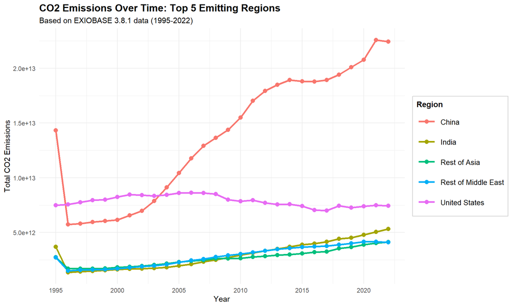

```r
# Create the time series plot
co2_plot <- ggplot(co2_timeseries, aes(x = year, y = total_co2, color = region_name)) +
    geom_line(linewidth = 1.2) +
    geom_point(size = 2.5) +
    labs(
        title = "CO2 Emissions Over Time: Top 5 Emitting Regions",
        subtitle = "Based on EXIOBASE 3.8.1 data (1995-2022)",
        x = "Year",
        y = "Total CO2 Emissions",
        color = "Region"
    ) +
    theme_minimal() +
    theme(
        plot.title = element_text(face = "bold", size = 14),
        legend.position = "right",
        legend.title = element_text(face = "bold", size = 11),
        legend.text = element_text(size = 10),
        legend.background = element_rect(fill = "white", color = "gray80"),
        legend.key.size = unit(1, "cm")
    ) +
    scale_x_continuous(breaks = seq(1995, 2022, by = 5))

co2_plot
```

```r
# Get CO2 emissions for all regions in 1995 and 2022
co2_1995 <- exio |>
    filter(year == 1995,
           matrix == "F_satellite",
           stressor %like% "%CO2%") |>
    group_by(region) |>
    summarise(co2_1995 = sum(value, na.rm = TRUE)) |>
    collect()

co2_2022 <- exio |>
    filter(year == 2022,
           matrix == "F_satellite",
           stressor %like% "%CO2%") |>
    group_by(region) |>
    summarise(co2_2022 = sum(value, na.rm = TRUE)) |>
    collect()

# Join the two datasets and calculate change
co2_change <- co2_1995 |>
    inner_join(co2_2022, by = "region") |>
    mutate(
        absolute_change = co2_2022 - co2_1995,
        percent_change = ((co2_2022 - co2_1995) / co2_1995) * 100
    ) |>
    filter(grepl("^W", region)) |>  # Include only rest-of-world regions (WA, WE, WF, WL, WM)
    arrange(absolute_change)

# View regions with the largest absolute decreases
head(co2_change, 5)
```

| region | co2_1995 | co2_2022 | absolute_change | percent_change |
| --- | --- | --- | --- | --- |
| WE | 9.030433e+11 | 6.712871e+11 | -231756217349 | -25.66391 |
| WL | 1.031966e+12 | 1.210434e+12 | 178467913386 | 17.29397 |
| WF | 6.193652e+11 | 1.045021e+12 | 425655682163 | 68.72451 |
| WM | 2.725564e+12 | 4.105235e+12 | 1379670736150 | 50.61964 |
| WA | 2.741959e+12 | 4.123570e+12 | 1381611732978 | 50.38777 |

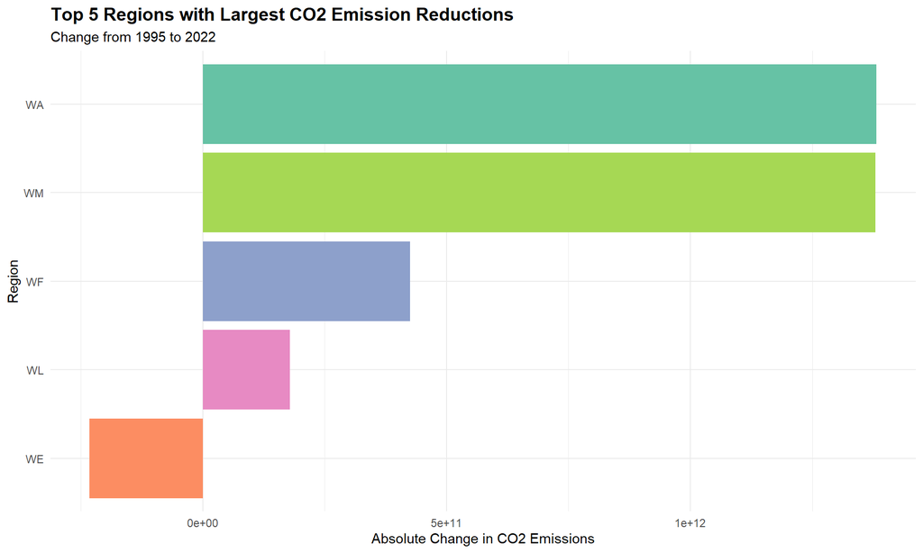

```r
# Get top 5 reducers
top_reducers <- co2_change |>
    head(5)

# Create a bar plot
reduction_plot <- ggplot(top_reducers, aes(x = reorder(region, absolute_change), y = absolute_change, fill = region)) +
    geom_col() +
    coord_flip() +
    scale_fill_brewer(palette = "Set2") +
    labs(
        title = "Top 5 Regions with Largest CO2 Emission Reductions",
        subtitle = "Change from 1995 to 2022",
        x = "Region",
        y = "Absolute Change in CO2 Emissions"
    ) +
    theme_minimal() +
    theme(
        plot.title = element_text(face = "bold", size = 14),
        legend.position = "none"
    )

reduction_plot
```

Let’s also look at percentage reductions (excluding countries with very low baseline emissions):

```r
# Filter to countries with substantial 1995 emissions (>1000 units) to avoid outliers
substantial_emitters <- co2_change |>
    filter(co2_1995 > 1000) |>
    arrange(percent_change) |>
    head(5)

substantial_emitters
```

| region | co2_1995 | co2_2022 | absolute_change | percent_change |
| --- | --- | --- | --- | --- |
| WE | 9.030433e+11 | 6.712871e+11 | -231756217349 | -25.66391 |
| WL | 1.031966e+12 | 1.210434e+12 | 178467913386 | 17.29397 |
| WA | 2.741959e+12 | 4.123570e+12 | 1381611732978 | 50.38777 |
| WM | 2.725564e+12 | 4.105235e+12 | 1379670736150 | 50.61964 |
| WF | 6.193652e+11 | 1.045021e+12 | 425655682163 | 68.72451 |

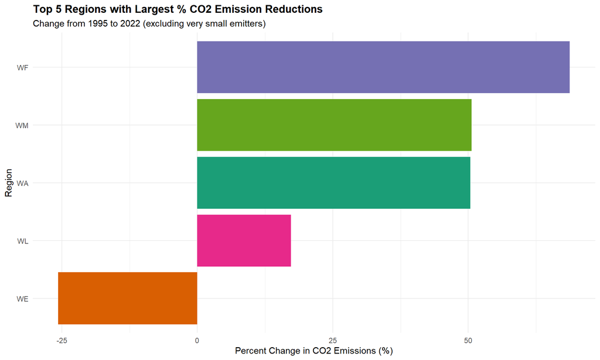

```r
# Visualize percentage reductions
percent_plot <- ggplot(substantial_emitters, aes(x = reorder(region, percent_change), y = percent_change, fill = region)) +
    geom_col() +
    coord_flip() +
    scale_fill_brewer(palette = "Dark2") +
    labs(
        title = "Top 5 Regions with Largest % CO2 Emission Reductions",
        subtitle = "Change from 1995 to 2022 (excluding very small emitters)",
        x = "Region",
        y = "Percent Change in CO2 Emissions (%)"
    ) +
    theme_minimal() +
    theme(
        plot.title = element_text(face = "bold", size = 13),
        legend.position = "none"
    )

percent_plot
```

## 8 Exercise 5: CO2 Emissions Over Time for Top 5 Emitting Countries

Now let’s look at individual countries (excluding rest-of-world aggregates) to see the top 5 emitting countries:

```r
# Find the top 5 emitting countries in 2022 (excluding W regions)
top_countries_2022 <- exio |>
    filter(year == 2022,
           matrix == "F_satellite",
           stressor %like% "%CO2%") |>
    group_by(region) |>
    summarise(total_co2 = sum(value, na.rm = TRUE)) |>
    filter(!grepl("^W", region)) |>  # Exclude rest-of-world regions
    arrange(desc(total_co2)) |>
    head(5) |>
    collect()

top_countries_2022
```

| region | total_co2 |
| --- | --- |
| CN | 2.243434e+13 |
| US | 7.430458e+12 |
| IN | 5.313784e+12 |
| RU | 3.117788e+12 |
| JP | 2.012722e+12 |

Get time series data for these top 5 countries across all years:

| year | region | total_co2 |
| --- | --- | --- |
| 1995 | CN | 1.433023e+13 |
| 1995 | IN | 3.696330e+12 |
| 1995 | JP | 2.213593e+12 |
| 1995 | RU | 2.902238e+12 |
| 1995 | US | 7.498717e+12 |
| 1996 | CN | 5.743286e+12 |
| 1996 | IN | 1.362128e+12 |
| 1996 | JP | 2.058099e+12 |
| 1996 | RU | 2.785685e+12 |
| 1996 | US | 7.558552e+12 |

[output cut: 10 more lines]

Create a line plot showing CO2 emissions over time for the top 5 countries:

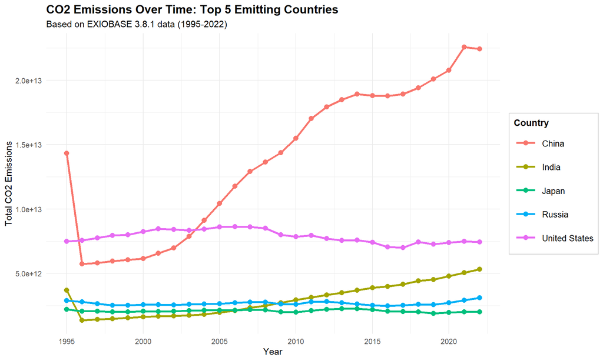

```r
# Create the time series plot
countries_plot <- ggplot(co2_countries_timeseries, aes(x = year, y = total_co2, color = country_name)) +
    geom_line(linewidth = 1.2) +
    geom_point(size = 2.5) +
    labs(
        title = "CO2 Emissions Over Time: Top 5 Emitting Countries",
        subtitle = "Based on EXIOBASE 3.8.1 data (1995-2022)",
        x = "Year",
        y = "Total CO2 Emissions",
        color = "Country"
    ) +
    theme_minimal() +
    theme(
        plot.title = element_text(face = "bold", size = 14),
        legend.position = "right",
        legend.title = element_text(face = "bold", size = 11),
        legend.text = element_text(size = 10),
        legend.background = element_rect(fill = "white", color = "gray80"),
        legend.key.size = unit(1, "cm")
    ) +
    scale_x_continuous(breaks = seq(1995, 2022, by = 5))

countries_plot
```